# Reproducible Research: Week 1 Project

## Loading Environment Packages/Etc.

In the code below, I am loading up environment variables and packages to ensure that the code can be run irrespective of the particular modules and packages that are already loaded on my machine.

```r
is.installed <- function(mypkg){
  is.element(mypkg, installed.packages()[,1])
}

if (!is.installed("data.table")){
  install.packages("data.table")
}

if (!is.installed("lubridate")){
  install.packages("lubridate")
}

if (!is.installed("ggplot2")){
  install.packages("ggplot2")
}

if (!is.installed("lattice")){
  install.packages("lattice")
}

if (!is.installed("knitr")){
  install.packages("knitr")
}

library(data.table)
library(lubridate)
library(ggplot2)
library(lattice)
library(knitr)
```

## Loading and preprocessing the data

In this step, I am loading up the data and assuming that it has already been unpacked via ZIP extraction or some other mechanism. The assignment did not require us to add code to specifically unzip the file.  
**Note** The code to deal with whether a given day of the week is a weekend or a weekday is used from the start.

```r
activityData <- read.csv('activity.csv', stringsAsFactors = FALSE)
activityData$date <- as.POSIXct(as.Date(activityData$date), format = "%Y-%M-%D")
activityFrame <- data.frame(Date = activityData$date,
                              WeekDay = tolower(weekdays(activityData$date)),
                              Steps = activityData$steps,
                              interval = activityData$interval
                            )

# Code below determines weekday/weekend distinction
activityFrame$DayType = ifelse(activityFrame$WeekDay == "saturday" | activityFrame$WeekDay == "sunday", "Weekend", "Weekday")
rm(activityData) # <-- Removing the data to save some space
```

# Calculate Total Number of Steps Per Day

In this block, I calculate the total number of steps per day and print the result to the resulting document. My original code generates PNG files; however, in this case, I chose to print the screen for the purpose of using RMarkdown and Knitr

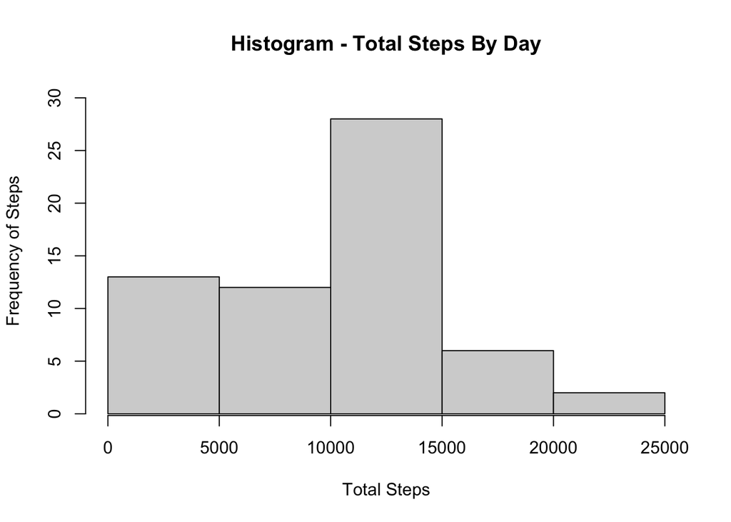

[output not shown]

```r
stepsByDay <- aggregate(activityFrame$Steps, by=list(activityFrame$Date), FUN = sum, na.rm = TRUE)
names(stepsByDay) <- c("Day", "TotalSteps")
p1 <- hist(stepsByDay$TotalSteps,
     xlab = "Total Steps",
     ylab = "Frequency of Steps",
     main = "Histogram - Total Steps By Day",
     ylim = range(1:30),
     col = "Light Grey"
)
```

# Calculate Mean/Median Of Steps Per Day

Below we extract the mean and median steps per day as requested and print them to the screen

```r
stepsmean <- mean(stepsByDay$TotalSteps)
stepsmedian <- median(stepsByDay$TotalSteps)
```

**Mean:** 9354.23  
**Median:** 10395

# What is the average daily activity pattern?

The code below creates a plot describing the daily activity pattern

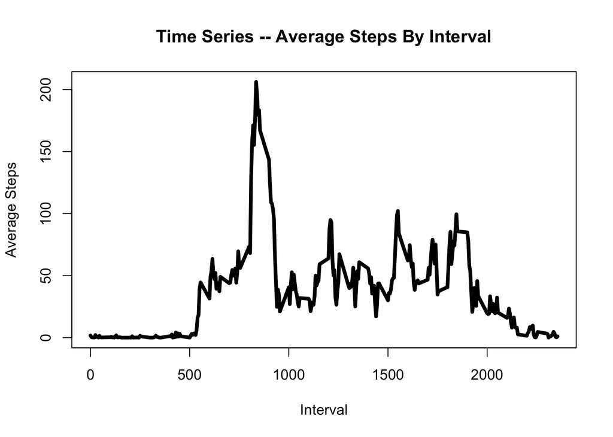

```r
intervalTimeSeries <- aggregate(activityFrame$Steps, by=list(activityFrame$interval), FUN = mean, na.rm = TRUE)
names(intervalTimeSeries) <- c("Interval","AverageSteps")
p2 <- plot(x = intervalTimeSeries$Interval,
     y = intervalTimeSeries$AverageSteps,
     lwd = 4,
     type = "l",
     xlab = "Interval",
     ylab = "Average Steps",
     main = "Time Series -- Average Steps By Interval",
     col = "Black"
)
```

## Find The Interval With Largest Max Value

Below I find the interval that has the largest max average steps value and print to the screen.

```r
# Find The Interval Corresponding To Max Mean
maxPosition <- which(intervalTimeSeries$AverageSteps == max(intervalTimeSeries$AverageSteps))
intervalValue = intervalTimeSeries[maxPosition, 1]
```

**Interval With Largest Max Value:** 835

## Imputing missing values

The code below is used to identify missing values and imput them

```r
# Find Number Of NA Values
naCount <- sum(is.na(activityFrame$Steps))

# Get Positions of NA Values
naPositions <- which(is.na(activityFrame$Steps))

# Imputed Values Creation
replacementVector <- rep(mean(activityFrame$Steps, na.rm=TRUE), times=length(naPositions))
activityFrame[naPositions, "Steps"] <- replacementVector
```

## Now plot everything again, this time with the values there.

The plot below looks at the total steps using the same basic histogram design, but this time with the imputed data

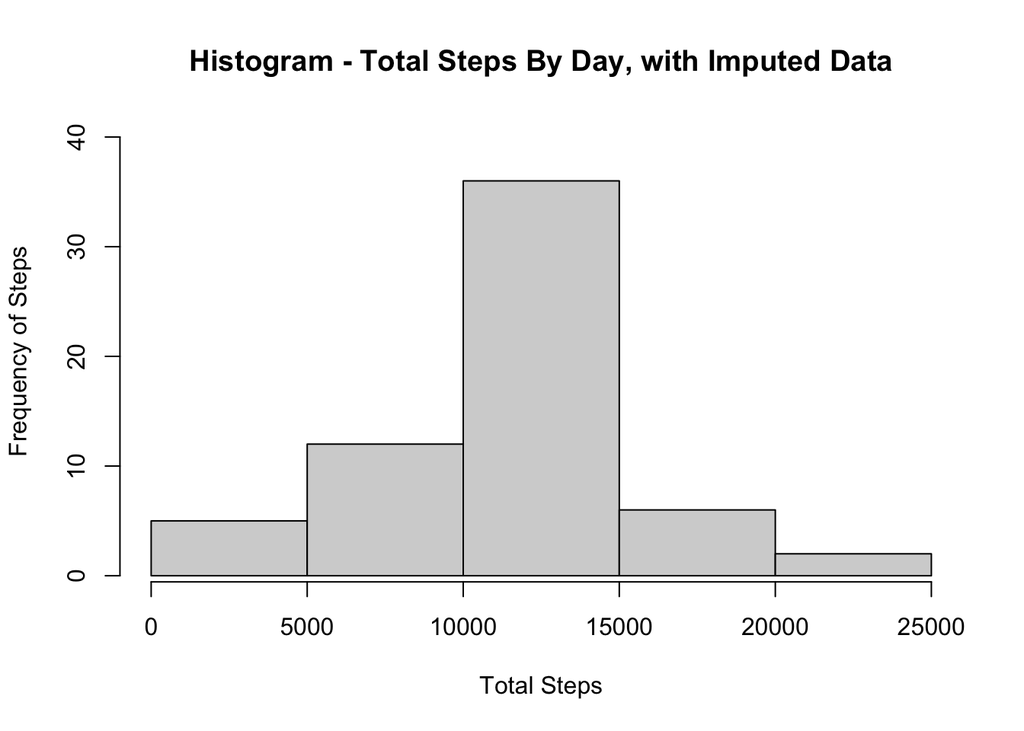

[output not shown]

## What Are The Revised Mean And Median

**Revised Mean:** 10766  
**Revised Median:** 10766

## Activity Pattern Differences Between Weekends and Weekdays

Below I do some processing to come up with the steps by weekend/weekday. Also, for some clarity and ease of plotting, I created two sub-tables “weekend” and “weekday” that allow for very straightforward plotting using R’s base plotting system

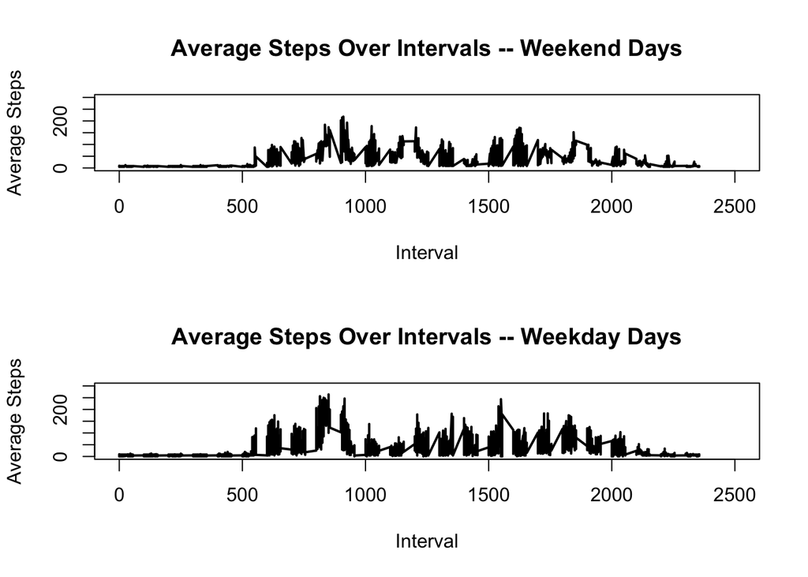

```r
# Now plot the average across day type
daytypeTable <- aggregate(activityFrame$Steps,
                          by=list(activityFrame$DayType, activityFrame$WeekDay, activityFrame$interval),
                          FUN = mean, na.rm = TRUE)

names(daytypeTable) <- c("DayType", "DayOfWeek", "Interval", "AverageSteps")
weekend <- subset(daytypeTable, DayType == "Weekend")
weekday <- subset(daytypeTable, DayType == "Weekday")

par(mfrow=c(2,1))
p4 <- plot(weekend$Interval, weekend$AverageSteps, type="l", lwd=2,
            col="Black", xlim=range(0:2500), ylim=range(0:300),
            xlab="Interval", ylab="Average Steps",
            main="Average Steps Over Intervals -- Weekend Days"
)

p4 <- p4 + plot(weekday$Interval, weekday$AverageSteps, type="l", lwd=2,
                col="Black", xlim=range(0:2500), ylim=range(0:300),
                xlab="Interval", ylab="Average Steps",
                main="Average Steps Over Intervals -- Weekday Days"
)
```